# Modeling Notebook: Group 1

Shane Nisley, Gustav Vollo, Louis Ackumey, Aiden Coutin

## Business Problem

Our business problem is to accurately forecast demand of Swire’s limited-release products, preventing both out-of-stocks and overproduction, and ensuring optimal production quantities that align with evolving consumer preferences. Achieving this goal will help Swire drive revenue growth and cost savings, expand market reach, and maintain a competitive edge in response to evolving consumer preferences and industry dynamics.

## Analytics Approach

This problem is a supervised regression problem, where the target variable is units sold over a period of time as a metric for Swire’s demand. The questions posed by Swire vary in character, but are all based on a desire to predict volume of sales (demand) over a period of time. Many modeling options (ARIMA, logistic regression, kNN, decision trees, among others) were explored, and ARIMA was selected as the final model development tool.

## Notebook Purpose

The intent of this notebook is to capture the modelling done to answer some of the questions (#6, #7) that Swire posed. This notebook contains data preprocessing efforts, aggregation and validation, results summary, and future steps.

## Load libraries

```r
# Dynamically loading required libraries using pacman for a cleaner and more efficient setup
library(dplyr)
library(forecast)
library(lubridate)
# pacman automatically checks for and installs missing packages

if (!require("pacman")) install.packages("pacman")
pacman::p_load(tidyverse, skimr, GGally, plotly, viridis,
               caret, DT, data.table, lightgbm, readr, e1071,
               ranger, parallel, mice, corrplot, ggplot2, C50, psych, caret, rminer, rmarkdown, stringr, matrixStats, kableExtra, knitr)

# Setting working directory to the specified path for consistent file access
#setwd(getwd())
#setwd("C:/Users/u1295825/OneDrive - University of Utah/Documents/Capstone2")
#setwd("C:\\Users\\amcou\\Documents\\GradSchool\\Classes\\S4 Spring 2024\\Capstone 3\\Assignments")

# Loading the dataset for analysis
merged_4 <- read.csv("merged_2.csv")
merged_2 <- merged_4 # for Q6 later
```

# Modeling Question 7

Here, we define the specific product characteristics that Swire plans to release, focusing on a particular flavor, packaging type, and brand. The goal is to predict demand over a 13-week period in the Southern region.

- Item description: Peppy Gentle Drink Pink Woodsy .5L Multi Jug
- Caloric: Regular
- Category: SSD
- Manufacturer: Swire-CC
- Brand: Peppy
- Package Type: .5L Multi Jug
- Flavor: ‘Pink Woodsy’
- Question: Swire plans to release this product in the Southern region for 13 weeks. What will the demand be, in weeks, for this product?

## Date manipulation

```r
# To begin with, we want to make new columns for Year, Month and Week.
# Preprocess the data
merged_4$DATE <- as.Date(merged_4$DATE)
merged_4$YEAR <- year(merged_4$DATE)
merged_4$MONTH <- month(merged_4$DATE)
merged_4$WEEK <- week(merged_4$DATE)
```

Recognizing that Weeks, Month and Year may influence future demand predictions, we prepared the data by extracting these time components for use in our models. By incorporating month and year into our dataset, we aim to capture seasonal and annual trends that could influence the demand for the new product. This transformation makes our dataset more suitable for time-series analysis or models that can account for temporal variations.

## Making a subset of filtered data for modeling

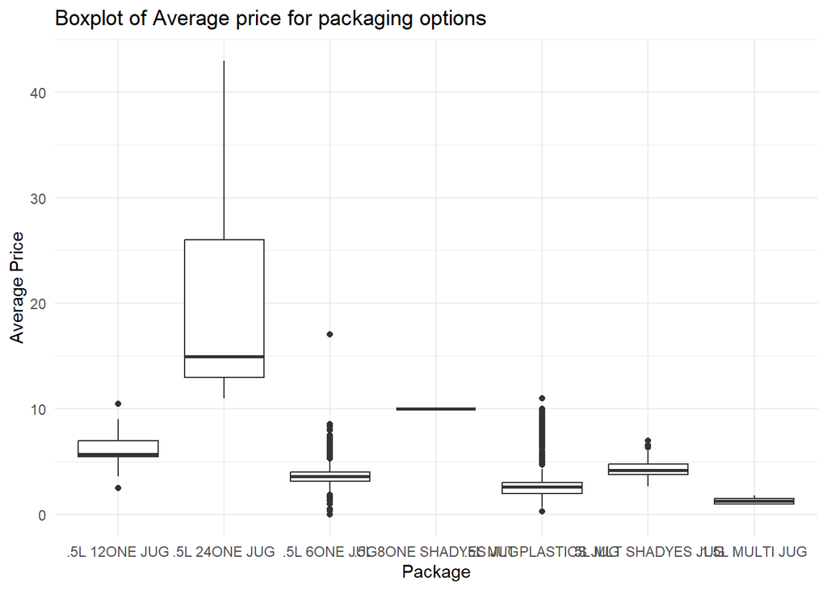

```r
library(stringr)

#To align our dataset with the product characteristics of interest, we filter `merged_4` for entries that match the given descriptions. This subset will serve as the basis for our demand prediction models.

# Filtering `merged_4` for entries that match our product criteria
q7_data <- merged_4 %>%
  select(everything()) %>%
  filter(CATEGORY == "SSD",
         grepl("PINK|WOODSY|PEPPY|GENTLE", ITEM, ignore.case = TRUE),
         str_detect(PACKAGE, fixed(".5L")),
         Region == "Southwest",
         CALORIC_SEGMENT == "REGULAR")

# Ensuring that UNIT_SALES contains only whole orders for consistency
q7_data <- q7_data[q7_data$UNIT_SALES %% 1 == 0,]

# Visualizing the distribution of average prices across different packaging options
ggplot(data = q7_data, aes(x = PACKAGE, y = AVG_PRICE)) +
  geom_boxplot() +
  theme_minimal() +
  labs(title = "Boxplot of Average price for packaging options",
       x = "Package",
       y = "Average Price")
```

The data is now saved as a filtered dataset where most of the characteristics replicate the description of the item in question 7. The initial data filtering highlights inconsistencies in packaging options and their associated pricing, which need standardization for accurate demand prediction.

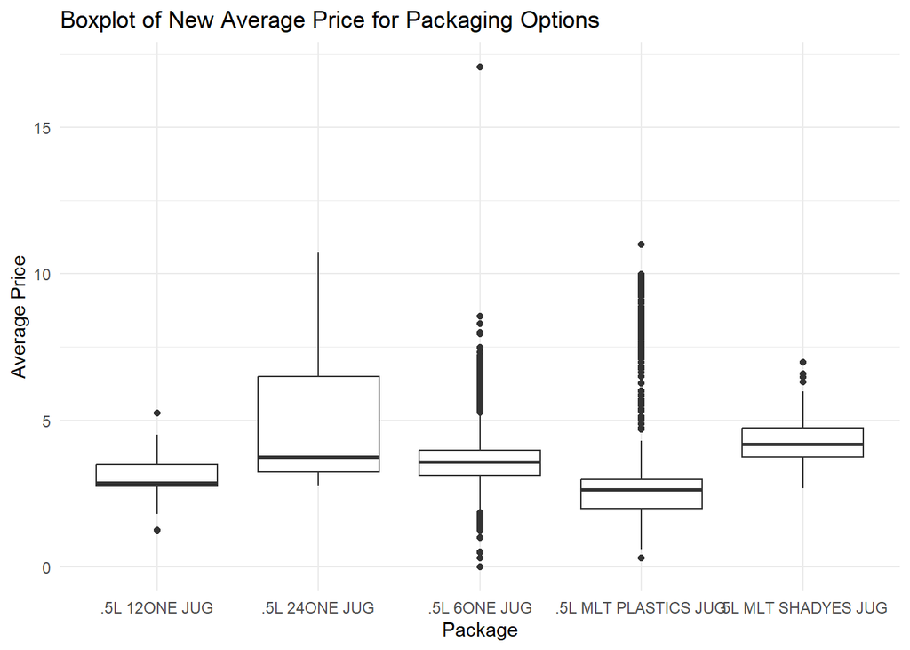

```r
# Standardizing UNIT_SALES to a comparable basis across different packaging options
q7_data <- q7_data %>%
  filter(PACKAGE != ".5L 8ONE SHADYES JUG", PACKAGE != "1.5L MULTI JUG") %>%
  mutate(
    UNIT_SALES = case_when(
      PACKAGE == ".5L 24ONE JUG" ~ UNIT_SALES * 4,
      PACKAGE == ".5L 12ONE JUG" ~ UNIT_SALES * 2,
      TRUE ~ UNIT_SALES
    )
  )

# Recalculating average price based on the standardized UNIT_SALES
q7_data$NEW_AVG_PRICE = q7_data$DOLLAR_SALES / q7_data$UNIT_SALES

# Re-visualizing the distribution of new average prices after standardization
ggplot(data = q7_data, aes(x = PACKAGE, y = NEW_AVG_PRICE)) +
  geom_boxplot() +
  theme_minimal() +
  labs(title = "Boxplot of New Average Price for Packaging Options",
       x = "Package",
       y = "Average Price")
```

We standardized the PACKAGES by adjusting UNIT_SALES to be similar to .5L 6ONE JUG. After standardizing UNIT_SALES, we can now compare numerical sales data across different PACKAGE labels on a like-for-like basis, paving the way for more accurate demand prediction.

## Make data ready for modeling

To simplify our modeling process, we remove columns that won’t be used in the prediction models due to redundancy or potential multicollinearity. We also ensure that categorical data is properly encoded.

```r
# Preparing the dataset by grouping by predictor columns and ensuring correct data types
q7_data2 <- q7_data %>%
  group_by(YEAR, WEEK, MANUFACTURER, BRAND, ITEM, PACKAGE)%>% # first grouping by all possible products
  summarize(UNIT_SALES_TOT = sum(UNIT_SALES))%>% # aggregating total unit sales per profuct per week
  group_by(YEAR, WEEK, MANUFACTURER, BRAND)%>% # Then grouping by only the predictor values
  summarize(UNIT_SALES_PROD = mean(UNIT_SALES_TOT)) # Lastly creating an average units per product by brand

# Converting the Week column to a factor to treat it as categorical data
q7_data2$WEEK <- factor(q7_data2$WEEK)
q7_data2$MANUFACTURER <- factor(q7_data2$MANUFACTURER)
q7_data2$BRAND <- factor(q7_data2$BRAND)
#q7_data2$PACKAGE <- factor(q7_data2$PACKAGE) # removing package to increase model prediction

# Displaying the first few rows of the cleaned dataset
head(q7_data2)
```

```
## # A tibble: 6 × 5
## # Groups:   YEAR, WEEK, MANUFACTURER [1]
##    YEAR WEEK  MANUFACTURER BRAND                                 UNIT_SALES_PROD
##   <int> <fct> <fct>        <fct>                                           <dbl>
## 1  2020 49    COCOS        BUBBLE JOY ADVANTAGEOUS                        24171.
## 2  2020 49    COCOS        BUBBLE JOY ADVANTAGEOUS CHERRY VANIL…            173
## 3  2020 49    COCOS        CHERRY FIZZ                                     4722
## 4  2020 49    COCOS        ELF BUBBLES                                    11089
## 5  2020 49    COCOS        FANTASMIC                                        258
## 6  2020 49    COCOS        MEXICAN BUBBLE JOY ADVANTAGEOUS                 3023
```

The dataset is now prepared for modeling, with categorical variables properly encoded and unrelated or redundant columns removed. This cleanup helps in reducing the complexity and improving the accuracy of the predictive models.

## Test Set Generation

We construct a hypothetical test set based on the product description provided by Swire. This set will be used to predict the demand for the specified product characteristics. As we want to predict for 13 weeks, there will be 13 rows in the dataset to predict.

```r
# Defining a new data frame to represent the specific product in question
question7 <- data.frame(
  MANUFACTURER = rep("SWIRE-CC", 13),
  BRAND = rep("PEPPY", 13),
  PACKAGE = rep(".5L 6ONE JUG", 13),
  WEEK = factor(seq(10, 22)),  # Sequence from week 10 to 22
  YEAR = rep(2024, 13)  # Replicate 2024 for each week
)
# We have used week 10 to 22 arbitrary, and this can be adjusted to fit more specific time frames.


# Calculating the total days of production based on the 13-week period

# Displaying the hypothetical test set and the calculated average price
print(question7)
```

```
##    MANUFACTURER BRAND      PACKAGE WEEK YEAR
## 1      SWIRE-CC PEPPY .5L 6ONE JUG   10 2024
## 2      SWIRE-CC PEPPY .5L 6ONE JUG   11 2024
## 3      SWIRE-CC PEPPY .5L 6ONE JUG   12 2024
## 4      SWIRE-CC PEPPY .5L 6ONE JUG   13 2024
## 5      SWIRE-CC PEPPY .5L 6ONE JUG   14 2024
## 6      SWIRE-CC PEPPY .5L 6ONE JUG   15 2024
## 7      SWIRE-CC PEPPY .5L 6ONE JUG   16 2024
## 8      SWIRE-CC PEPPY .5L 6ONE JUG   17 2024
## 9      SWIRE-CC PEPPY .5L 6ONE JUG   18 2024
## 10     SWIRE-CC PEPPY .5L 6ONE JUG   19 2024
## 11     SWIRE-CC PEPPY .5L 6ONE JUG   20 2024
## 12     SWIRE-CC PEPPY .5L 6ONE JUG   21 2024
## 13     SWIRE-CC PEPPY .5L 6ONE JUG   22 2024
```

## Model Validation

```r
# Setting a seed for reproducibility
set.seed(10)

# Creating indices for the training set
inTrain <- createDataPartition(y = q7_data2$UNIT_SALES_PROD, p = 0.70, list = FALSE)

# Splitting the dataset into training and testing sets
train_target <- q7_data2[inTrain, 5]
test_target <- q7_data2[-inTrain, 5]
train_input <- q7_data2[inTrain, -5]
test_input <- q7_data2[-inTrain, -5]

train_target <- unlist(train_target)
test_target <- unlist(test_target)

# Specifying a list of metrics for model evaluation
metrics_list <- c("MAE", "RMSE", "MAPE", "RMSPE", "RAE", "RRSE", "R2")
```

## Model 1: Linear Regression

First, we employ a linear regression model. This model will attempt to predict the demand based on a linear relationship between the predictor variables and the target variable.

```r
# Training the linear regression model on the training data
model2 <- lm(train_target ~ ., data = train_input)

# Making predictions using the linear model on both training and test data
train_predictions2 <- predict(model2, train_input)
test_predictions2 <- predict(model2, test_input)

# Evaluating the performance of the linear model using predefined metrics
train_result <- mmetric(train_target, train_predictions2, metrics_list)
test_result <- mmetric(test_target, test_predictions2, metrics_list)

train_result
```

```
##          MAE         RMSE         MAPE        RMSPE          RAE         RRSE
## 1474.8713403 2566.0900491 2139.2281537 1147.3510944   29.7364382   35.0285519
##           R2
##    0.8773001
```

```r
test_result
```

```
##          MAE         RMSE         MAPE        RMSPE          RAE         RRSE
## 1561.6712353 2752.6919480 1844.0185606  997.6512330   31.4081663   37.5337444
##           R2
##    0.8591866
```

```r
# Reviewing the model summary to understand the significance of predictors
summary(model2)
```

```
##
## Call:
## lm(formula = train_target ~ ., data = train_input)
##
## Residuals:
##      Min       1Q   Median       3Q      Max
## -16266.4   -955.0    -51.4    842.8  27648.2
##
## Coefficients: (2 not defined because of singularities)
##                                               Estimate Std. Error t value
## (Intercept)                                 2108033.22  122452.93  17.215
## YEAR                                          -1041.87      60.58 -17.197
## WEEK2                                          -455.65     507.15  -0.898
## WEEK3                                          -173.20     498.35  -0.348
## WEEK4                                         -1232.04     496.53  -2.481
## WEEK5                                           228.88     514.19   0.445
## WEEK6                                            49.39     510.33   0.097
## WEEK7                                           -13.42     516.56  -0.026
## WEEK8                                          -405.22     537.05  -0.755
## WEEK9                                           -76.59     509.10  -0.150
## WEEK10                                          709.07     507.63   1.397
## WEEK11                                          660.54     527.53   1.252
## WEEK12                                         1289.95     518.31   2.489
## WEEK13                                           73.87     508.82   0.145
## WEEK14                                        -1160.05     517.70  -2.241
## WEEK15                                         -167.07     499.79  -0.334
## WEEK16                                          379.68     498.36   0.762
## WEEK17                                         -471.81     501.38  -0.941
## WEEK18                                          346.36     506.14   0.684
## WEEK19                                           30.69     507.09   0.061
## WEEK20                                          264.53     509.05   0.520
## WEEK21                                          -35.06     505.54  -0.069
## WEEK22                                        -1485.73     497.08  -2.989
## WEEK23                                          406.97     507.16   0.802
## WEEK24                                         -130.92     508.55  -0.257
## WEEK25                                           84.31     497.03   0.170
## WEEK26                                           67.59     493.05   0.137
## WEEK27                                        -1494.87     498.22  -3.000
## WEEK28                                          483.79     494.63   0.978
## WEEK29                                          594.63     498.59   1.193
```

[output cut: 160 more lines]

```
## BRANDPEPPY SUNSHINE BERRY                    < 2e-16 ***
## BRANDROOT BEER WONDER                       1.09e-08 ***
## BRANDROYAL COLA                              < 2e-16 ***
## BRANDSINGLE GROUP                           0.028663 *
## BRANDSIZZLE ROOT BEER                       0.105959
## BRANDSMASH                                   < 2e-16 ***
## BRANDSPARKLING JACCEPTABLETLESTER            < 2e-16 ***
## BRANDVANILLA BUBBLE JOY ADVANTAGEOUS              NA
## BRANDYAWN                                         NA
## ---
## Signif. codes:  0 '***' 0.001 '**' 0.01 '*' 0.05 '.' 0.1 ' ' 1
##
## Residual standard error: 2604 on 3221 degrees of freedom
## Multiple R-squared:  0.8773, Adjusted R-squared:  0.8736
## F-statistic: 239.9 on 96 and 3221 DF,  p-value: < 2.2e-16
```

```r
rmse_lm <- test_result[["RMSE"]]
rsq_lm <- test_result[["R2"]]

# Predicting demand for the specific product scenario with the linear model
Swire_pred_lm <- predict(model2, question7)
```

The linear regression model provides a straightforward approach to understand how each predictor influences the target variable. Evaluating its performance gives us a benchmark against which to compare more complex models. Based on the similarity in prediction for test and train, we can confirm that the model is fit well. Linear regression is often easier to interpret, and we can see from the model summary that Year is negatively trading and that each week are predicting different demand, which may imply some seasonality and a decrease in demand over time.

From the model summary, we can also see how volatile each different line is. It seems that linear regression is capturing most of the products pretty well due to the way we have aggregated the data.

As we can see from this linear regression, we are able to achieve a relatively high R-squared of .86 and RMSE of 2752. This model is a good benchmark for the upcoming models.

The downside with the linear regression is that with few products matching the question 7 description, like BRAND = PEPPY only has a few matching products. Therefore, it will be very biased towards the PEPPY product that appears to be a popular product based on weekly sales ranging over 50,000 units.

## Model 2: KNN with IBk

Next, we explore a K-Nearest Neighbors model using the IBk algorithm. KNN is a simple yet effective technique for regression and classification tasks. It will smooth out our issues with having few PEPPY products from linear regression.

```
# Model could not be run for knitting due to issues with Java. The results will be hardcoded instead.
# Training the KNN model
library(RWeka)
model1 <- IBk(train_target ~ .,data = train_input, control = Weka_control(K=4, I = TRUE)) # running it with 4 closest and weighted average

# Making predictions on both the training and test sets
train_predictions1 <- predict(model1, train_input)
test_predictions1 <- predict(model1, test_input)

# Evaluating model performance
train_result <- mmetric(train_target, train_predictions1, metrics_list)
test_result <- mmetric(test_target, test_predictions1, metrics_list)

train_result
test_result

rmse_ibk <- test_result[["RMSE"]]
rsq_ibk <- test_result[["R2"]]

# Predicting demand for the specific product and adjusting by production days and average price
Swire_pred_IBk <- predict(model1, question7)
```

This model could not be run for knitting due to issues with Java. The results will be hard coded instead. The KNN model gave an R-squared of 0.87 and RMSE of 2955.

```r
# Hardcode for later table
rmse_ibk <- 2955.32
rsq_ibk <- 0.8686
Swire_pred_IBk <- 59222.43
```

This is a better R-squared than the linear regression model but has a worse RMSE. This model selects four of the closest products and creates a weighted average, in contrast to the linear regression that predicts on the one PEPPY item in the dataset. We believe this model makes a better guess at what this new product will look like in terms of demand.

## Model 3: Decision Tree with Rpart

As a third approach, we explore a decision tree model using the `rpart` package. Decision trees can capture non-linear relationships and interactions between predictors.

```r
library(rpart)
#install.packages("rpart.plot")
library(rpart.plot)

# Training the decision tree model on the training set
model3 <- rpart(train_target ~ ., data = train_input)

# Making predictions with the decision tree model on both training and test sets
train_predictions3 <- predict(model3, train_input)
test_predictions3 <- predict(model3, test_input)

# Evaluating the decision tree model's performance
train_result <- mmetric(train_target, train_predictions3, metrics_list)
test_result <- mmetric(test_target, test_predictions3, metrics_list)

train_result
```

```
##          MAE         RMSE         MAPE        RMSPE          RAE         RRSE
## 1566.2323533 2445.0388213 2840.2659791 1300.7023847   31.5784641   33.3761355
##           R2
##    0.8886034
```

```r
test_result
```

```
##          MAE         RMSE         MAPE        RMSPE          RAE         RRSE
## 1652.8268776 2913.7124897 2425.1450841 1132.2921243   33.2414789   39.7293057
##           R2
##    0.8426959
```

```r
#rpart.plot(model3) #model makes no good plot

rmse_rpart <- test_result[["RMSE"]]
rsq_rpart <- test_result[["R2"]]

# Predicting demand for the Swire product using the decision tree model
Swire_pred_rpart <- predict(model3, question7)
```

Similar to the linear regression, we also see that the metrics for predicting both test and train set are slightly off, implying a chance of overfitting or underfitting. This model has higher errors than linear regression across the board, with a lower R2 too. The model is also easy to interpret and can be used to understand importance of variable. We do however consider this model to be biased, similar to the reasons that linear regression may have a high bias. With few PEPPY products, the projections from this model may not necessarily be accurate despite high r-squared.

## ARIMA Forecasing

By adding ARIMA forecasting to our analysis, which already includes IBK, rpart, and linear regression models, we gain a deeper understanding of sales trends over time, something the initial models might miss. This approach not only makes our sales predictions more reliable by using a method tailored for time series data but also gives us a solid basis for comparison, enhancing the overall accuracy of our forecast.

```r
#First, we will use the filtered q7_data from previous manipulation and filtering.
similar_products <- q7_data
```

### Sales Analysis

For ARIMA, we want to do weekly projections. We would need to aggregate sales by year, week and item to find unit sales for each brand per week before aggregating the total average weekly unit sales.

```r
# Aggregate weekly sales data
weekly_sales <- similar_products %>%
  group_by(YEAR, WEEK, ITEM) %>%
  summarize(total_unit_sales = sum(UNIT_SALES)) %>%
  group_by(YEAR, WEEK) %>%
  summarize(total_unit_sales = mean(total_unit_sales))
```

### Sales Forecasting with ARIMA

Fit an ARIMA model to the time series data and forecast future sales, without taking seasonality into consideration.

```r
# Create a time series object
sales_ts <- ts(weekly_sales$total_unit_sales, frequency=52, start=c(2021, which(weekdays(as.Date("2020-12-05")) == "Saturday")))

# Fit an ARIMA model
fit <- auto.arima(sales_ts)

#calculate in-sample fitted values
fitted_values <- fitted(fit)

#calculate residuals
residuals <- sales_ts - fitted_values

#calculate RMSE
rmse <- sqrt(mean(residuals^2,na.rm=TRUE))
print(paste("RMSE:",rmse))
```

```
## [1] "RMSE: 1226.61516872408"
```

```r
# Total sum of squares
tss <- sum((sales_ts-mean(sales_ts))^2)

#Sum of squares residuals
rss <- sum(residuals^2)

#R-squared
rsq <- 1-(rss/tss)
print(paste("R-squared:",rsq))
```

```
## [1] "R-squared: 0.37229775265185"
```

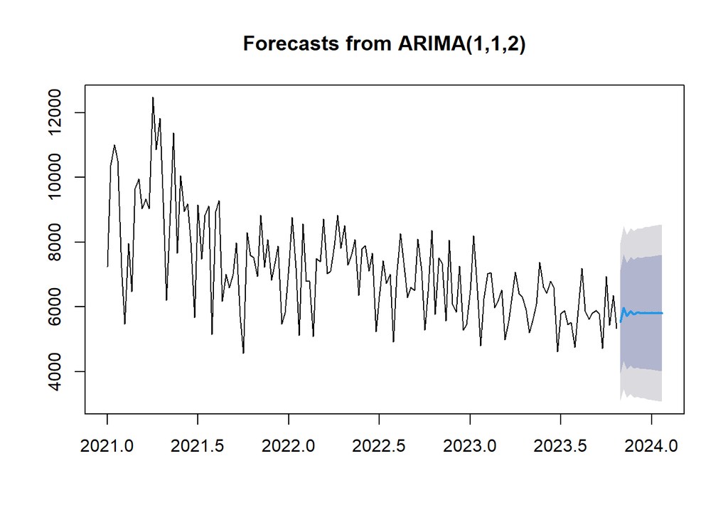

```r
# Forecast the next 26 weeks
forecasted_sales <- forecast(fit, h=13)

# Plot the forecast
plot(forecasted_sales)
```

```r
# Print and sum the forecasted mean sales values
print(forecasted_sales$mean)
```

```
## Time Series:
## Start = c(2023, 44)
## End = c(2024, 4)
## Frequency = 52
##  [1] 5542.406 5974.876 5710.894 5872.030 5773.672 5833.710 5797.063 5819.432
##  [9] 5805.778 5814.113 5809.025 5812.130 5810.235
```

```r
sum(forecasted_sales$mean)
```

```
## [1] 75375.36
```

From the ARIMA model, we see that the average sales are trending slightly down, and the 13 week forecast period is forecast as a fairly straight line.

### Sales Forecast with ARIMA, Adjusted for Seasonality

```r
# arima
sales_ts <- ts(weekly_sales$total_unit_sales, frequency=52, start=c(2021, which(weekdays(as.Date("2020-12-05")) == "Saturday")))

# Include the intervention in the ARIMA model using the xreg argument
fit <- auto.arima(sales_ts, seasonal = TRUE, D = 1, max.P = 2, max.Q = 2, max.order = 5, stepwise = FALSE, approximation = FALSE)

#calculate in-sample fitted values
fitted_values <- fitted(fit)

#calculate residuals
residuals <- sales_ts - fitted_values

#calculate RMSE
rmse2 <- sqrt(mean(residuals^2,na.rm=TRUE))
print(paste("RMSE:",rmse2))
```

```
## [1] "RMSE: 1044.69255163017"
```

```r
# Total sum of squares
tss <- sum((sales_ts-mean(sales_ts))^2)

#Sum of squares residuals
rss <- sum(residuals^2)

#R-squared
rsq2 <- 1-(rss/tss)
print(paste("R-squared:",rsq2))
```

```
## [1] "R-squared: 0.544682840163869"
```

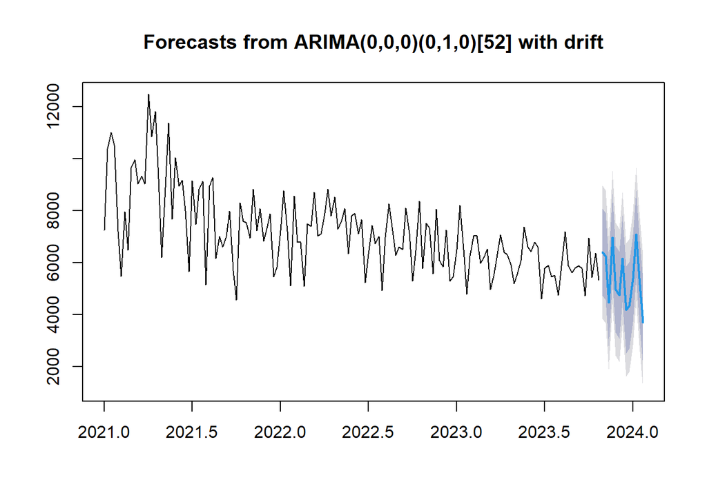

```r
# Forecast with the future values of the launch period
forecasted_sales2 <- forecast(fit, h=13)

plot(forecasted_sales2)
```

```r
print(forecasted_sales2$mean)
```

```
## Time Series:
## Start = c(2023, 44)
## End = c(2024, 4)
## Frequency = 52
##  [1] 6399.758 6233.316 4461.083 6961.548 4977.595 4738.990 6150.990 4182.851
##  [9] 4352.333 5393.455 7092.874 5392.804 3689.367
```

```r
sum(forecasted_sales2$mean)
```

```
## [1] 70026.96
```

We now see the forecast trending similar to the projections. Our R-squared and RMSE is also improved from the previous ARIMA model. We also see that the sales are more weekly dependent than what first thought.

This ARIMA model is great for seeing the volatility, looking at confidence intervals and gaining insight on future demand. Although R-squared is relatively low (0.54, which is lower than for the previous modeling methods), we believe that this model has better potential.

Time series models are great for analyzing and forecasting data that varies over time, enabling the identification of underlying patterns such as trends, seasonality, and cycles for decision-making or predictive purposes. This is exactly what Swire is looking for with this product.

## Comparative Analysis and Conclusion

Having developed and evaluated five different models - KNN, linear regression, decision tree, ARIMA, and ARIMA with seasonality - we now have a comprehensive view of potential demand for the new product. Each model offers unique insights and trade-offs in terms of accuracy, complexity, and interpretability.

```r
# Comparing predicted demand across models
predicted_demands <- data.frame(
  Model = c("KNN", "Linear Regression", "Decision Tree", "ARIMA","ARIMA Seasonal"),
  Predicted_Demand = c(sum(Swire_pred_IBk),
                       sum(Swire_pred_lm),
                       sum(Swire_pred_rpart),
                       sum(forecasted_sales$mean),
                       sum(forecasted_sales2$mean)),
  Predicted_R_Squared = c(rsq_ibk,
                          rsq_lm,
                          rsq_rpart,
                          rsq,
                          rsq2),
  Predicted_RMSE = c(rmse_ibk,
                     rmse_lm,
                     rmse_rpart,
                     rmse,
                     rmse2)
)

# Displaying the predicted demands for review
kable(predicted_demands, caption = "Predicted Demands by Model")
```

Predicted Demands by Model

| Model | Predicted_Demand | Predicted_R_Squared | Predicted_RMSE |
| --- | --- | --- | --- |
| KNN | 59222.43 | 0.8686000 | 2955.320 |
| Linear Regression | 222459.07 | 0.8591866 | 2752.692 |
| Decision Tree | 214178.87 | 0.8426959 | 2913.712 |
| ARIMA | 75375.36 | 0.3722978 | 1226.615 |
| ARIMA Seasonal | 70026.96 | 0.5446828 | 1044.693 |

In conclusion, we see that our more traditional models with linear regression and rpart are predicting with a higher r-squared. The RMSE cannot be compared to the ARIMA, as ARIMA uses a different type of weekly aggregated data.

The real take-away from this is the range for product demand. With the different models we get a range between 59,000 and 222,500 units for demand over 13 weeks. This is a very wide range that make this prediction hard to really trust. In our humble opinion, the KNN and ARIMA with seasonality have more reasonable results and may be better applied for changes in item description.

Next, we want to learn about demand specifically during the launch period of a new product.

## Analysis of Launch Period

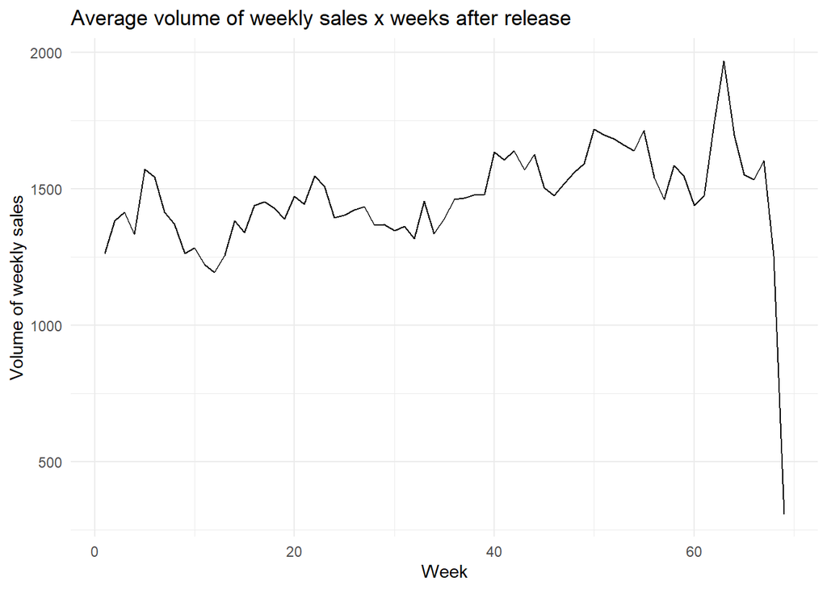

```r
# Filter new_release dataset for items first appearing after 01-01-2021
new_release <- similar_products %>%
  group_by(ITEM) %>%
  summarize(first_appearance = min(DATE), last_app = max(DATE)) %>%
  filter(first_appearance > as.Date("2021-01-01"))

# Filter similar_products for items matching those in new_release
filtered_new_release <- similar_products %>%
  filter(ITEM %in% new_release$ITEM)

# Calculate Week_Index for each item and aggregate sales weekly
index_data <- filtered_new_release %>%
  arrange(ITEM, DATE) %>%
  group_by(ITEM, YEAR, WEEK) %>%
  mutate(Week_Index = row_number())

new_rel <- index_data%>%
  group_by(ITEM, Week_Index)%>%
  summarise(sale_weekly = sum(UNIT_SALES))


# Plot the mean weekly sales by Week_Index after the release of items
filt_new <- new_rel %>%
  group_by(Week_Index) %>%
  summarize(sales_post_rel = mean(sale_weekly))

ggplot(filt_new, aes(x = Week_Index, y = sales_post_rel)) +
  geom_line() +
  labs(title = "Average volume of weekly sales x weeks after release",
       x = "Week",
       y = "Volume of weekly sales") +
  theme_minimal()
```

## Conclusion

This analysis provided a comprehensive overview of the sales trends for a specific product category. Starting from preprocessing the data to applying predictive modeling, like kNN, linear regression and rpart, to time series modeling with ARIMA for sales forecasting. We have extracted valuable insights into potential sales dynamics over the coming months. Further, by filtering for new product releases and analyzing sales trends post-release, we now can better understand the impact of new products on overall sales performance.

For this specific product, we have defined the 13-week demand to be in units. Our recommendation is that the total demand will be in the range between 55,000 and 80,000 for the 13 weeks. There will be some variation, from week-to-week, with a likely peak around 5-6 weeks in.

# Modeling Question 6

- Item Description: Diet Energy Moonlit Casava 2L Multi Jug
- Caloric Segment: Diet
- Category: Energy
- Manufacturer: Swire-CC
- Brand: Diet Moonlit
- Package Type: 2L Multi Jug
- Flavor: ‘Cassava’
- Question: Swire plans to release this product for 6 months. What will the forecasted demand be, in weeks, for this product?

```r
merged_3 <- merged_2 # merged_2 <- read.csv("merged_2.csv") # from above

# Step 1: Preprocess the data
# Convert DATE to a Date type and extract useful features
merged_3$DATE <- as.Date(merged_3$DATE)
merged_3$YEAR <- year(merged_3$DATE)
#merged_3$month <- month(merged_3$DATE)
#merged_3$day <- day(merged_3$DATE)
merged_3$WEEK <- week(merged_3$DATE)
```

## Methodology and Filtering

To begin, we explored numerous methodologies to answer this question. A significant amount of our time was dedicated to machine learning models, which were largely incapable of producing a prediction due to data constraints related to the product in question. Consequently, we opted for the ARIMA method. However, we encountered several limitations with this approach as well. Below is our best attempt to navigate these issues, leveraging the available data and making informed assumptions.

```r
multi <- merged_3 |>
  filter(PACKAGE == "2L MULTI JUG")

small <- merged_3 |>
  filter(PACKAGE == "16SMALL MULTI CUP")

sum(small$UNIT_SALES)/sum(multi$UNIT_SALES)
```

```
## [1] 1.700116
```

```r
first_appearance <- merged_3 %>%
  filter(CATEGORY == "ENERGY",
         MANUFACTURER == "SWIRE-CC") %>%
  group_by(ITEM, MANUFACTURER) %>%
  summarize(first_appearance_date = min(DATE),
            last_appearnace = max(DATE))

print(first_appearance)
```

```
## # A tibble: 15 × 4
## # Groups:   ITEM [15]
##    ITEM                       MANUFACTURER first_appearance_date last_appearnace
##    <chr>                      <chr>        <date>                <date>
##  1 "ONLY ORGANIC ENERGY DRIN… SWIRE-CC     2023-03-04            2023-03-04
##  2 "VENOMOUS BLAST ENERGY DR… SWIRE-CC     2020-12-05            2023-10-28
##  3 "VENOMOUS BLAST ENERGY DR… SWIRE-CC     2020-12-05            2023-10-28
##  4 "VENOMOUS BLAST ENERGY DR… SWIRE-CC     2021-01-23            2021-01-23
##  5 "VENOMOUS BLAST ENERGY DR… SWIRE-CC     2022-10-29            2023-04-15
##  6 "VENOMOUS BLAST ENERGY DR… SWIRE-CC     2021-12-25            2022-01-08
##  7 "VENOMOUS BLAST ENERGY DR… SWIRE-CC     2020-12-05            2023-10-28
##  8 "VENOMOUS BLAST ENERGY DR… SWIRE-CC     2020-12-05            2023-10-28
##  9 "VENOMOUS BLAST ENERGY DR… SWIRE-CC     2021-02-27            2023-03-18
## 10 "VENOMOUS BLAST ENERGY DR… SWIRE-CC     2020-12-05            2023-10-28
## 11 "VENOMOUS BLAST ENERGY DR… SWIRE-CC     2020-12-26            2023-07-22
## 12 "VENOMOUS BLAST ENERGY DR… SWIRE-CC     2021-02-27            2022-12-10
## 13 "VENOMOUS BLAST ENERGY DR… SWIRE-CC     2020-12-05            2023-10-28
## 14 "VENOMOUS BLAST ENERGY DR… SWIRE-CC     2020-12-05            2023-10-28
## 15 "VENOMOUS BLAST ENERGY DR… SWIRE-CC     2020-12-05            2023-10-28
```

```r
x <- merged_3 |>
      filter(CATEGORY == "ENERGY") |>
      group_by(MANUFACTURER, PACKAGE) |>
      summarise(totalUnits = sum(UNIT_SALES))

print(x, n = 50)
```

```
## # A tibble: 58 × 3
## # Groups:   MANUFACTURER [8]
##    MANUFACTURER PACKAGE                totalUnits
##    <chr>        <chr>                       <dbl>
##  1 ALLYS        12SMALL 24ONE CUP         507428.
##  2 ALLYS        12SMALL MULTI CUP      263393101.
##  3 ALLYS        16SMALL 12ONE CUP         118912.
##  4 ALLYS        16SMALL MULTI CUP       27513692.
##  5 ALLYS        2SMALL MULTI JUG/CUP          19
##  6 ALLYS        8SMALL 12ONE CUP         8076162.
##  7 ALLYS        8SMALL 24ONE CUP         1242745.
##  8 ALLYS        8SMALL 4ONE CUP         13553978.
##  9 ALLYS        8SMALL MULTI CUP       105729692.
## 10 ALLYS        ALL OTHER ONES          24947857.
## 11 BEARS        16SMALL MULTI CUP         277213
```

[output cut: 40 more lines]

For the energy drink, we had to make certain concessions in our demand modeling. There were no historical observations of energy drinks matching the size or flavor that Swire wants to introduce, and given Swire’s limited history with energy drinks, utilizing data from other manufacturers appeared inadvisable. The primary rationale was Swire’s guidance that overestimation is far more costly than underestimation, and other, more established manufacturers have significantly higher demand levels. Additionally, for this, we needed to standardize demand based on package size. Our exploration into Swire’s sales data for energy drinks revealed that 99% of all sales were attributable to one size: the 16SMALL MULTI CUP. Hence, we examined all market data to compare sales of the 2L Multi Jug against the 16S Multi and deduced that, on average, 1.7 cups are sold for every Jug. Consequently, we adjusted our final projection based on this ratio.

```r
# Filter data for products matching specific criteria
similar_products <- merged_3 %>%
  filter(CALORIC_SEGMENT == "DIET/LIGHT",
         CATEGORY == "ENERGY",
         PACKAGE == "16SMALL MULTI CUP",
         MANUFACTURER == "SWIRE-CC") %>%
  filter(UNIT_SALES > 0)
```

## ARIMA Model Development

```r
# Aggregate weekly sales data of similar products
weekly_sales <- similar_products %>%
  group_by(YEAR, WEEK, ITEM) %>%
  summarize(total_unit_sales = sum(UNIT_SALES))

weekly_sales <- weekly_sales %>%
  group_by(YEAR, WEEK) %>%
  summarize(total_unit_sales = mean(total_unit_sales)) %>%
  filter(YEAR < 2022)


# arima
sales_ts <- ts(weekly_sales$total_unit_sales, frequency=52, start=c(2021, which(weekdays(as.Date("2020-12-05")) == "Saturday")))


launch_period <- ifelse(time(sales_ts) >= 2021 & time(sales_ts) < 2021.5, 1, 0)

# Include the intervention in the ARIMA model using the xreg argument
fit <- auto.arima(sales_ts, xreg = launch_period, seasonal = TRUE, D = 1, max.P = 2, max.Q = 2, max.order = 5, stepwise = FALSE, approximation = FALSE)

#launch period effect only impacts the first 26 weeks
future_launch_period <- rep(0, 26) # No launch effect in the future

# Forecast with the future values of the launch period
forecasted_sales <- forecast(fit, xreg = future_launch_period, h=26)

## ***
# Fit an ARIMA model
#fit <- auto.arima(sales_ts)
# Forecast the next 26 weeks (6 months)
#forecasted_sales <- forecast(fit, h=26)
## ***
```

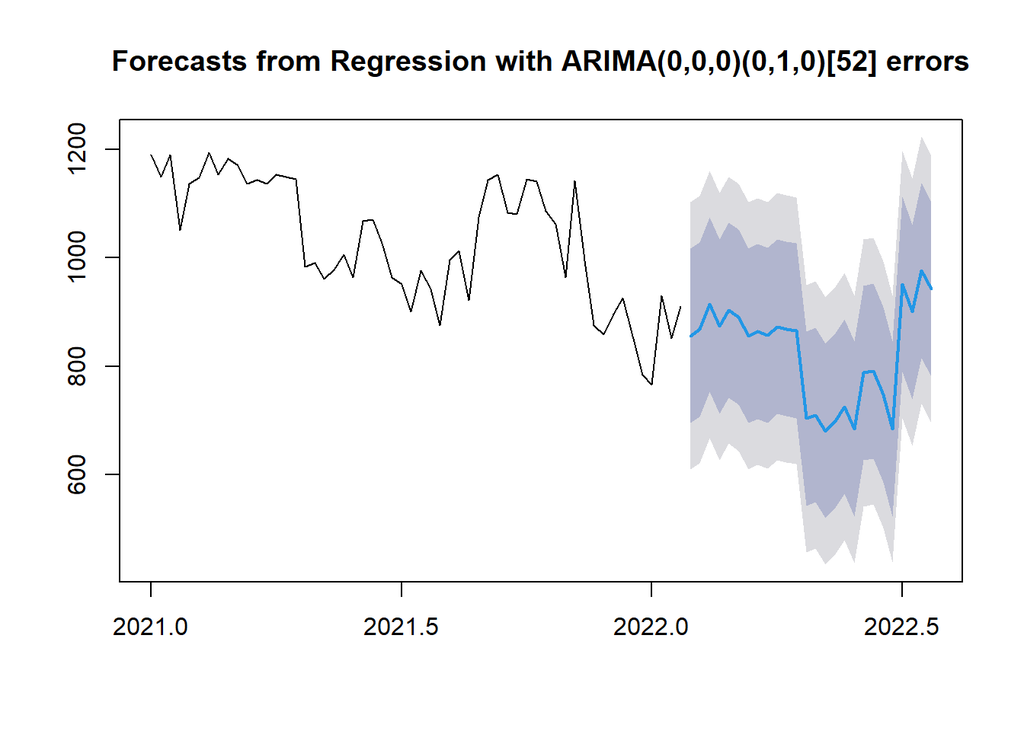

```r
# forecast plot
plot(forecasted_sales)
```

```r
# Forecast values mean
print(forecasted_sales$mean)
```

```
## Time Series:
## Start = c(2022, 5)
## End = c(2022, 30)
## Frequency = 52
##  [1] 856.25 868.00 914.50 873.50 903.75 890.75 856.50 864.25 857.25 873.25
## [11] 869.00 865.75 703.50 710.00 680.50 697.75 725.75 684.25 787.75 791.25
## [21] 747.75 684.50 951.25 900.25 977.00 942.50
```

```r
# values & CI
print(forecasted_sales)
```

```
##          Point Forecast   Lo 80    Hi 80    Lo 95     Hi 95
## 2022.077         856.25 695.058 1017.442 609.7282 1102.7718
## 2022.096         868.00 706.808 1029.192 621.4782 1114.5218
## 2022.115         914.50 753.308 1075.692 667.9782 1161.0218
## 2022.135         873.50 712.308 1034.692 626.9782 1120.0218
## 2022.154         903.75 742.558 1064.942 657.2282 1150.2718
## 2022.173         890.75 729.558 1051.942 644.2282 1137.2718
## 2022.192         856.50 695.308 1017.692 609.9782 1103.0218
## 2022.212         864.25 703.058 1025.442 617.7282 1110.7718
## 2022.231         857.25 696.058 1018.442 610.7282 1103.7718
## 2022.250         873.25 712.058 1034.442 626.7282 1119.7718
## 2022.269         869.00 707.808 1030.192 622.4782 1115.5218
## 2022.288         865.75 704.558 1026.942 619.2282 1112.2718
## 2022.308         703.50 542.308  864.692 456.9782  950.0218
## 2022.327         710.00 548.808  871.192 463.4782  956.5218
## 2022.346         680.50 519.308  841.692 433.9782  927.0218
## 2022.365         697.75 536.558  858.942 451.2282  944.2718
## 2022.385         725.75 564.558  886.942 479.2282  972.2718
## 2022.404         684.25 523.058  845.442 437.7282  930.7718
## 2022.423         787.75 626.558  948.942 541.2282 1034.2718
## 2022.442         791.25 630.058  952.442 544.7282 1037.7718
## 2022.462         747.75 586.558  908.942 501.2282  994.2718
## 2022.481         684.50 523.308  845.692 437.9782  931.0218
## 2022.500         951.25 790.058 1112.442 704.7282 1197.7718
## 2022.519         900.25 739.058 1061.442 653.7282 1146.7718
## 2022.538         977.00 815.808 1138.192 730.4782 1223.5218
## 2022.558         942.50 781.308 1103.692 695.9782 1189.0218
```

```r
# Calculate in-sample fitted values
fitted_values <- fitted(fit)

# Calculate residuals
residuals <- sales_ts - fitted_values

# Calculate RMSE
rmse <- sqrt(mean(residuals^2, na.rm = TRUE))
print(paste("RMSE:", rmse))
```

```
## [1] "RMSE: 29.1121265094287"
```

```r
# Total Sum of Squares
tss <- sum((sales_ts - mean(sales_ts))^2)

# Sum of Squares of Residuals
rss <- sum(residuals^2)

# R-squared
rsq <- 1 - (rss / tss)
print(paste("R-squared:", rsq))
```

```
## [1] "R-squared: 0.935224084680473"
```

```r
adjust1 <- sum(forecasted_sales$mean) / 1.7

adjust2 <- adjust1*1.081

adjust3 <- adjust2*1.081

predicted_demand <- round(adjust3,0)

print(paste("Predicted Demand For 6 Months:",predicted_demand))
```

```
## [1] "Predicted Demand For 6 Months: 14763"
```

## Conclusion

The remaining challenges in forecasting this product stemmed from the modeling process. Machine learning was not a feasible option, given our current proficiency and the lack of relevant predictive data. After innumerable attempts and failing to identify a contemporary algorithm for our needs, we reverted to what we felt we were best at, attempting to bridge any gaps as best we could. The modeling approach may seem odd at first glance. We are forecasting data from 2021 to estimate demand for 2024. This route was chosen to account for the significant initial surge in sales following a product launch. Subsequent to the initial orders, natural demand tends to decline substantially over time. Accordingly, we modeled the launch period of the most comparable subset of beverages available. To calculate the final demand, we incorporated the package conversion ratio, tempering the projection to what the Jug’s demand would likely be, and then accounted for two years of market growth at 8.1% (cited above), in our final estimate. Ultimately, we advise conducting additional market research or surveys to refine projections based on the desired launch flavor, since Swire has not previously produced energy drinks in the flavor they plan to launch with this product.

### https://finance.yahoo.com/news/united-states-energy-drink-market-223000902.html

# Overall Recommendations and Future Work

Both output models would benefit from having more data available to the model. With potentially limited data sources currently, the performance metrics of each new product released should be used to supplement the current data in the model and used to re-train the model for future predictions. This would effectively function as an integrated ARIMA and reinforcement-learning model, which would also provide some sensitivity towards changing market attitudes over time.

Every model has a nominal predictive value, which is what is typically reported and most used in decision making. This is a suboptimal approach when the penalty for overprediction is different from the penalty of underprediction. With a developed model, we can determine confidence intervals for a given point as well as calculating the nominal (mean) value. Assuming a normal distribution, the optimal production level for Swire can be determined to balance the risk of over- vs under-production, since the relative cost over overproduction is 4x the cost of out-of-stock (from one of Swire meetings).

The UNIT_SALES over time were predicted by the models generated herein. It appears that Swire’s initial business concern was about VOLUME of fluid to produce. Developing a conversion between PACKAGE and VOLUME, and integrating that with overall UNIT_SALES would allow analysts to develop a model predicting the amount of fluid sold. This would allow Swire to know and optimize how much flavor (as a physical substance) to order from Coke-Atlanta (from earlier discussion with Swire), which also provides a package-independent analysis. The PACKAGE variable could then be used to focus Swire’s production on the most successful packaging types.

# Appendix

## Other Tested, Unused Concepts

The ITEM variable contained details captured by the PACKAGE variable, which meant groupings based on ITEM were not as reduced as they could be. If modelling processed used in the future do not account for this, the aggregations may not function as intended. The models used in this analysis aggregated or filtered the data via PACKAGE, which meant that this issue was avoided.

The ITEM variable was also parsed to determine the flavor of each drink (ranging from zero to four flavors). This derived variable was initially filtered upon to use a more representative dataset, but when combining this with other filters (PACKAGE, CATEGORY), the dataset became too small to generate predictive models. CATEGORY and PACKAGE were selected as more important than flavor, but in future potential analysis where PACKAGE is integrated into a volume value for otherwise identical products, the size of the dataset may be maintained and flavor could become a predictor.

In non-time series analysis looking at aggregate sales, MARKET_KEY is a highly-predictive variable. Aggregating the data across market keys significantly reduced the performance of the models. For non-ARIMA analysis, the recommendation is to include MARKET_KEY (or STATE) as a predictive factor variable, and then sum the predictions across the market keys in question to arrive at a total sales value.

## Contribution

- Initial model exploration: Shane, Gus, Louis, Aiden
- Detailed model exploration: Shane, Gus
- Write-up and proofreading: Aiden, Louis